# STAT 240

Week 7: Regression and Prediction

Owen G. Ward

## Today

- See another regression method, K-Nearest Neighbors
- Consider how to compare the performance of these two regression methods, prediction tools in general

## Logistics

- Midterm Solutions and grades posted in the next week or so
- I’ll spend time going through common issues next week also

## Quick Recap - Linear Regression

- Assume we have input $X = (X_1,\ldots,X_n)$ and output $Y = (Y_1,\ldots,Y_n)$ (example: $X_i$ is month index, $Y_i$ is demand for product A)
- We assume that the “true” demand is $f(X_i) = \alpha + \beta X_i$
- The “observed” demand is a noisy version of the “true” demand: $\alpha + \beta X_i + \epsilon_i$

$$\begin{align}
\widehat \beta = \displaystyle\frac{\sum_{i=1}^n(X_i - \bar X)(Y_i - \bar Y)}{\sum_{i=1}^n(X_i - \bar X)^2}, & &
\widehat \alpha = \bar Y - \widehat\beta \bar X.
\end{align}$$

## Model Checking for Linear Regression

- Linear regression relies on some basic assumptions, that underlie the theory behind this model
- Assumes the true model we saw 1 slide ago
- Can we check those assumptions?
  - Yes, but not in this class (Stat 302/305)
  - We will focus on comparing this model using prediction

## Back to original example

```r
library(RSQLite)
db <- dbConnect(SQLite(), dbname = "xcoretail.sqlite")
dbListTables(db)
```

```
[1] "prices" "sales"
```

```r
library(DBI)
months <- sprintf("2011-%02d", 1:12)
counts <- rep(NA, 12)
for(i in 1:length(counts)) {
  query <- sqlInterpolate(db, "SELECT SUM(Quantity) FROM sales
                        WHERE StockCode = '71053' AND
                        InvoiceDate LIKE ?month",
  month = paste0(months[i], "%") )
  request <- dbSendQuery(db, query)
  counts[i] <- as.numeric(dbFetch(request))
  dbClearResult(request)
}
```

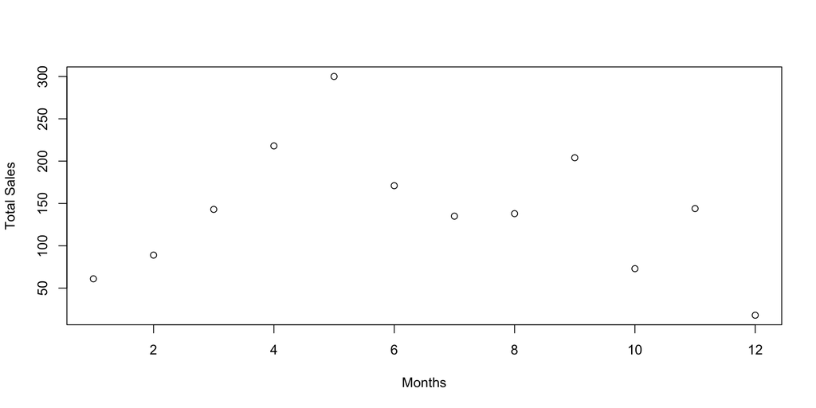

```r
plot(x = 1:12, y = counts, xlab = "Months", ylab = "Total Sales")
```

## Predicting the next month

- Suppose it’s October 1st and we want to predict how many sales there will be in the month
- Can we do this using linear regression?
  - Yes
- How do we decide if our model is any good?
  - Compare it to the true number of sales

## Prediction

- Lets fit a linear regression to the first 9 months

```r
x <- 1:9
y <- counts[1:9]

fit <- lm(y ~ x)
fit
```

```
Call:
lm(formula = y ~ x)

Coefficients:
(Intercept)            x
     107.44        10.93
```

## Prediction

- This gives us a fitted model

$$\widehat{f}(X_i) = \widehat{\alpha} + \widehat{\beta}X_i$$

- We could just evaluate this when $X_i=10$ for the next month

$$\widehat{f}(X_i = 10) = 107.44 + 10.93 \times 10 = 216.74$$

- Is this a good prediction?

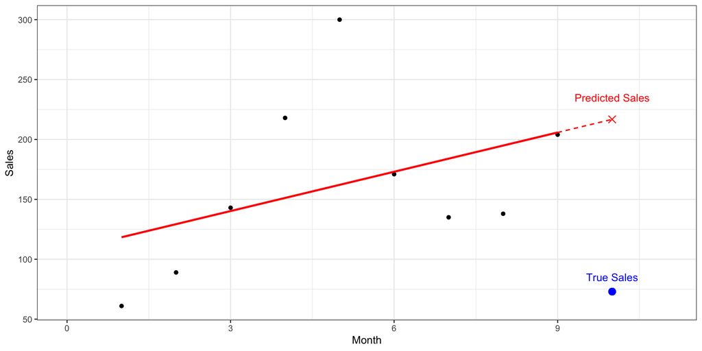

## Measuring Prediction

- We could compare the estimate to the true value, in terms of squared difference, a similar quantity to that used to fit the regression model initially
- For new data $x_{new},y_{new}$, which was not used to fit the model, compute

$$\text{Prediction Error} = (y_{new} - \widehat{f}(x_{new}))^2$$

$$\text{Prediction Error} = (y_{new} - \widehat{f}(x_{new}))^2$$

- For this problem

```r
alpha_hat <- as.numeric(coef(fit)[1])
beta_hat <- as.numeric(coef(fit)[2])
alpha_hat
```

```
[1] 107.4444
```

```r
beta_hat
```

```
[1] 10.93333
```

```r
y_hat <- alpha_hat + beta_hat * 10
Error <- (y_hat - counts[10])^2
Error
```

```
[1] 20672.05
```

- This is just a number, can’t do anything with just a single number

## Evaluating Predictions

- Come back to this after (very briefly) introducing an alternative method for doing prediction

# K-Nearest Neighbours

## Other prediction methods

- We have seen one initial method for predicting a numeric quantity, linear regression
- This is a simple but essential data science method
- We will now see another key method, which is quite different

## A Quick Note

- For the previous example, we wanted to predict the sales for the next month only, when $x_{new} = x + 1$
- This is kind of a special case, we want our method to be able to predict at any value of $x$ normally
- We will see this in our next example and in all future examples

## House Price Data

- Here we will use data about the sale price of ~1000 houses sold in California in 2008

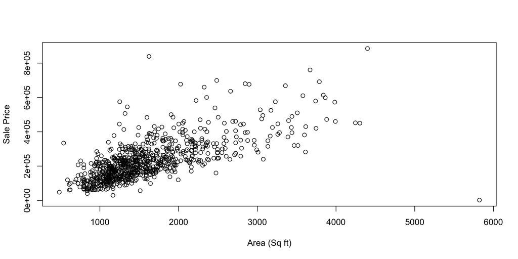

```r
house_sales <- read.csv("house_prices.csv")
plot(x = house_sales$area, y = house_sales$price, xlab = "Area (Sq ft)",
     ylab = "Sale Price")
```

## A Different Prediction Approach

- Suppose we want to predict the sale price of a new house (not in this dataset) which has an area of 2500 sq ft?
- We could do this with regression, find the value of $\widehat{\alpha} +\widehat{\beta}\times 2500$
- This requires the assumptions of a linear regression
- Instead, lets do something very simple

## Neighbors

- Find the 10 rows in our dataset with $x$ value “closest” to the one we want to predict at
- Get the average of $Y$ for these 10 rows
- Use that as the prediction for a new house with $X=2500$

## What this looks like

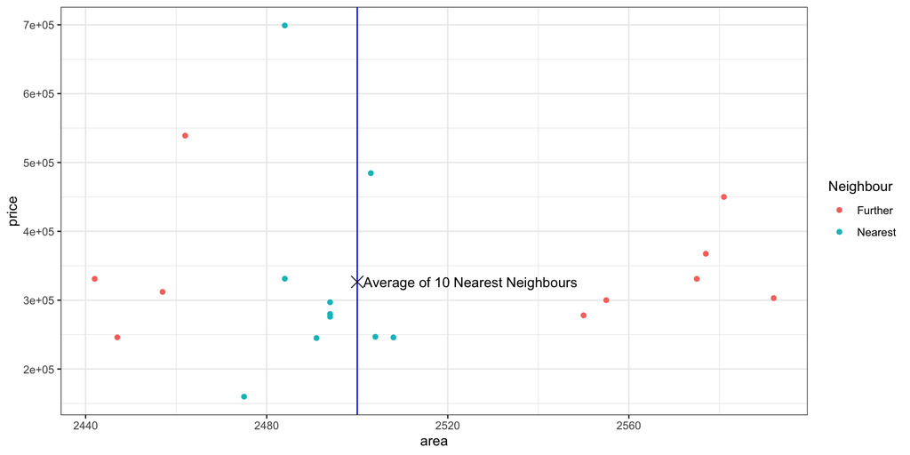

## Notes

- How do we decide what points are closest?
- Squared distance, $(X - 2500)^2$
- Would this work if we had instead chosen the 3 nearest points?
- End up with a very similar estimate (for this example)

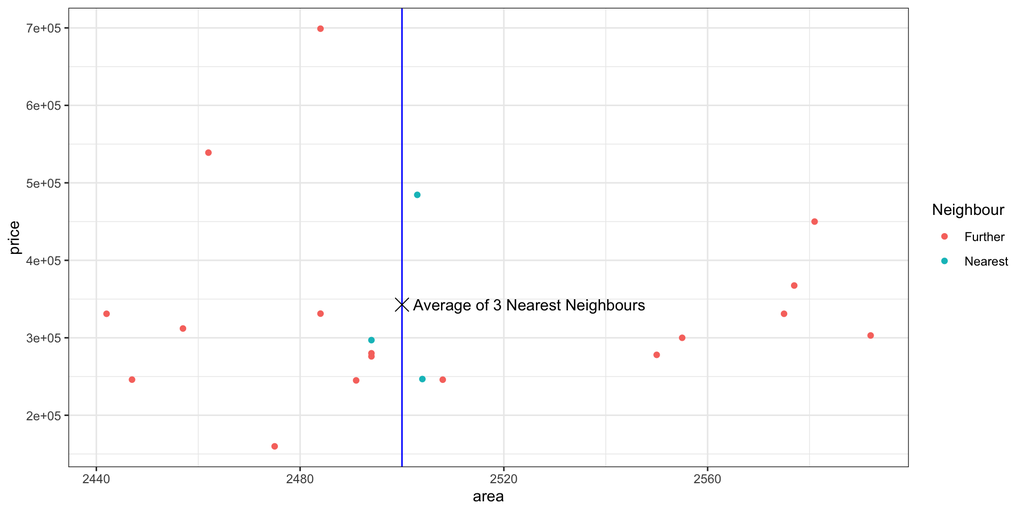

## K-Nearest Neighbours

- This is the K in the name!
- How many neighbours do we use in our model?
- What is the right value of $K$ for this problem?
- The solution to this is the same as the one needed to compare our linear regression model from before

# Comparing Prediction Methods

## Fitting a Model to Data

- Think back to how we fit linear regression
  - We find the model which minimizes the sum of squared errors on our data!
- This gives us the best possible regression model for our data
- But we want to see if its the best model for new/different data
- Several ways to do this

## Training and Test Data

- Suppose we were trying to see how good our regression model is at predicting house prices here
- If this is all the data we have, we need to find a way to get “new” data
- The way to do this is to split our dataset into:
  - A training set
  - A test set
- Estimate our model using the training data
- See how good it does at predicting the test data
  - Because we didn’t use the test data for fitting the model, this is predicting on new data
- This is the standard way to evaluate models used for prediction
- We just need some metric for performance on the test data

## Test Data

- The test data has to be “new” data
- Data that was not used to estimate the model initially
- Otherwise we are cheating, won’t really tell us how good the model is at predicting
  - Known as overfitting

## The Exact Procedure for Linear Regression

- We have data $(X_i, Y_i)$
- We randomly put 70% of this data in the training set and 30% in the test set (the proportions can vary)
- We estimate $\widehat{\alpha}$ and $\widehat{\beta}$ using **only the training data**
- We see how good the model is at predicting $Y$ in the test data

## What this looks like

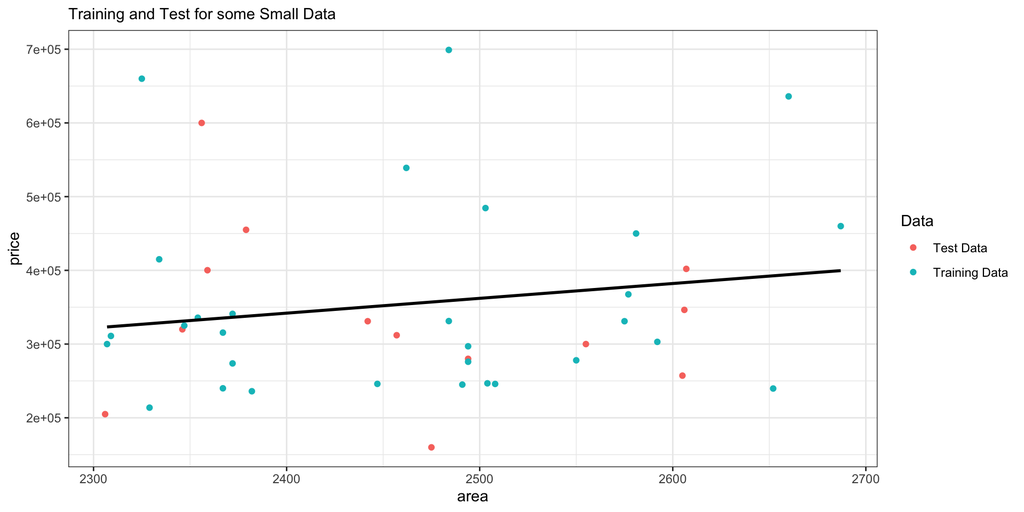

## Measuring Performance

- We need a measure of “performance” on the test data
- For a single point earlier we considered

$$\text{Prediction Error} = (y_{new} - \widehat{f}(x_{new}))^2$$

- We need something like this, for all data in the test set
- Average it across the data in the test set

## RMSPE

For $(X_i^{test},Y_{i}^{test})$ in the test set we will compute

$$RSMPE = \sqrt{\frac{1}{n_{test}}\sum_{i=1}^{n_{test}}(Y_{i}^{test} - \widehat{f}(X_{i}^{test}))^2}$$

- Here $\widehat{\alpha}$ and $\widehat{\beta}$ are computed from the training data!
- Then $\widehat{f}(X_{i}^{test})= \widehat{\alpha}+\widehat{\beta}X_{i}^{test} = \widehat{Y}_i^{test}$
- The point on the fitted line, for the $X$ in the test set
- This is the Root Mean Squared Predicted Error

## Computing this

- Let’s split this house price data into a training and test split and compute the RMSPE

```r
set.seed(240)
prop_train <- 0.7
prop_test <- 1 - prop_train

n_data <- nrow(house_sales)

train_test <- sample(c("Train", "Test"),
                     size = n_data, replace = TRUE,
                     prob = c(prop_train, prop_test))
head(train_test)
```

```
[1] "Train" "Test"  "Train" "Train" "Train" "Train"
```

```r
head(train_test == "Train")
```

```
[1]  TRUE FALSE  TRUE  TRUE  TRUE  TRUE
```

## Splitting the data

```r
train_data <- house_sales[train_test == "Train", ]
test_data <- house_sales[train_test == "Test",]

nrow(train_data)/n_data
```

```
[1] 0.7149877
```

```r
nrow(test_data)/n_data
```

```
[1] 0.2850123
```

- `train_test` a vector indicating which rows are in which, then we subset using this to separate the data into the two subsets

## Fit to Training Data

```r
fit_train <- lm(price ~ area, data = train_data)
fit_train
```

```
Call:
lm(formula = price ~ area, data = train_data)

Coefficients:
(Intercept)         area
    30894.1        124.7
```

- These estimates will change if we have a different training set

## Exercise

- Rerun the code to create the training and test sets, using a different seed (which will lead to a different sample). Confirm the estimates of $\alpha$ and $\beta$ change when you do.

## Solution

## Getting Predictions

- Now we need to get predictions for $Y$ for our test data
- We can use the R function `predict` to do this

```r
est_Y <- predict(fit_train, newdata = test_data)
head(est_Y)
```

```
       2       13       14       16       19       21
176446.0 139527.9 158111.7 172330.1 104231.3 170334.5
```

- These are our estimates of $\widehat{Y}_{i}^{test}$
- `predict` fits the model `fit_train`, using the $X$ values from `test_data` (i.e, it knows $X$ is `area`)

## Computing RMSPE

- We need to compute
  $$RMSPE = \sqrt{\frac{1}{n_{test}}\sum_{i=1}^{n_{test}}(Y_{i}^{test} - \widehat{f}(X_{i}^{test}))^2}$$
- This is the same as

$$RMSPE = \sqrt{\frac{1}{n_{test}}\sum_{i=1}^{n_{test}}(Y_{i}^{test} - \widehat{Y}_{i}^{test})^2}$$

- We just computed `est_Y` and can get $Y_{i}^{test}$ from `test_data$price`

```r
RMSPE <- sqrt( mean( (est_Y - test_data$price) ^2) )
RMSPE
```

```
[1] 76317.91
```

- We have no other model to compare this to, can’t really say if it’s good or bad

## Fitting KNN

- We will briefly fit KNN to this data next with $K=5$
- We’ll spend more time on this next week, but for now will just see how to do it

```r
library(caret)

fit_knn <- knnreg(price ~ area, data = train_data, k = 5)
est_Y_knn <- predict(fit_knn, test_data)
head(est_Y_knn)
```

```
[1] 135550.0 103313.2 144102.8 144098.0 103723.7 152950.0
```

## Compute RMSPE

```r
RMSPE_knn <- sqrt( mean( (est_Y_knn - test_data$price) ^2) )
RMSPE_knn
```

```
[1] 82518.13
```

- This is larger than the RMSPE for linear regression, indicates that linear regression can better predict house prices using the area, for this data
- Compared to KNN with $K=5$. But why $K=5$?

## Exercise

- Refit KNN with $K=10$
- What is the RMSPE for this model on the test data?

## Solution

## Caveat

- This is a very brief/simplistic introduction to evaluating prediction models
- There are lots of important considerations we’re avoiding
- If you take Stat 452 you’ll spend a lot more time on this!

## Choosing K

- We get different RMSPE for different choices of K…
- How do we know which one is best?
- Is there a way to find the “best” value of K?

## Next Time

- We will talk in more detail about the KNN model
- How to choose the optimal value of $K$
- How to use KNN for another key data science task, classification